# Tutorial 5: Dispersión y comparación de distribuciones

Estadística I — Matemáticas Aplicadas y Computación

Dra. Elizabeth Martínez Gómez

# Propósito

Dos conjuntos pueden tener medias similares y comportamientos muy distintos.

Aquí estudiaremos:

- rango;
- rango intercuartílico;
- varianza;
- desviación estándar;
- coeficiente de variación;
- comparación entre grupos.

Trabajaremos con las mediciones reales de diámetro de tres máquinas del NIST. El conjunto contiene 180 observaciones. [NIST, MACHINE.DAT](https://www.itl.nist.gov/div898/handbook/datasets/MACHINE.DAT).

```r
knitr::opts_chunk$set(echo = TRUE, message = FALSE, warning = FALSE)

library(ggplot2)

setwd("/home/nani/Documents/Universidad/2027-I/Estadistica/Actividades/Tutoriales estadística")
machine <- read.csv("Datos/Dana Amador - MACHINE.csv")
attach(machine)

names(machine)
```

```
## [1] "MACHINE"  "DAY"      "TIME"     "SAMPLE"   "DIAMETER"
```

```r
str(machine)
```

```
## 'data.frame':    180 obs. of  5 variables:
##  $ MACHINE : int  1 1 1 1 1 1 1 1 1 1 ...
##  $ DAY     : int  1 1 1 1 1 1 1 1 1 1 ...
##  $ TIME    : int  1 1 1 1 1 1 1 1 1 1 ...
##  $ SAMPLE  : int  1 2 3 4 5 6 7 8 9 10 ...
##  $ DIAMETER: num  0.125 0.126 0.125 0.125 0.126 ...
```

La variable categórica MACHINE debe ser factor y no entera. Por eso la convertimos:

```r
machine$MACHINE <- factor(machine$MACHINE)

str(machine)
```

```
## 'data.frame':    180 obs. of  5 variables:
##  $ MACHINE : Factor w/ 3 levels "1","2","3": 1 1 1 1 1 1 1 1 1 1 ...
##  $ DAY     : int  1 1 1 1 1 1 1 1 1 1 ...
##  $ TIME    : int  1 1 1 1 1 1 1 1 1 1 ...
##  $ SAMPLE  : int  1 2 3 4 5 6 7 8 9 10 ...
##  $ DIAMETER: num  0.125 0.126 0.125 0.125 0.126 ...
```

# 1. Rango

$$R=x_{\max}-x_{\min}.$$

```r
range(machine$DIAMETER)
```

```
## [1] 0.1202 0.1279
```

```r
diff(range(machine$DIAMETER))
```

```
## [1] 0.0077
```

## Actividad 1

¿Por qué el rango utiliza sólo dos observaciones?

¿Qué problema puede producir esto cuando hay un valor extremo?

# 2. Rango intercuartílico

$$IQR=Q_3-Q_1.$$

```r
quantile(machine$DIAMETER, c(.25, .75))
```

```
##    25%    75%
## 0.1229 0.1250
```

```r
IQR(machine$DIAMETER)
```

```
## [1] 0.0021
```

El IQR describe la amplitud del 50% central de las observaciones.

# 3. Varianza

Para una muestra:

$$s^2=\frac{1}{n-1}
\sum_{i=1}^n(x_i-\bar{x})^2.$$

```r
var(machine$DIAMETER)
```

```
## [1] 2.44344e-06
```

## Actividad 2 — Cálculo manual

Para:

```r
z <- c(2, 4, 5, 7)
```

calcula manualmente:

1. media;
2. desviaciones respecto a la media;
3. cuadrados;
4. suma de cuadrados;
5. varianza muestral.

Comprueba:

```r
mean(z)
```

```
## [1] 4.5
```

```r
var(z)
```

```
## [1] 4.333333
```

# 4. Desviación estándar

$$s=\sqrt{s^2}.$$

```r
sd(machine$DIAMETER)
```

```
## [1] 0.001563151
```

La desviación estándar vuelve a las unidades originales.

Esto es importante:

- varianza: unidades al cuadrado;
- desviación estándar: mismas unidades que la variable.

# 5. Comparar las máquinas

```r
aggregate(
  DIAMETER ~ MACHINE,
  data = machine,
  FUN = function(x) c(
    media = mean(x),
    mediana = median(x),
    sd = sd(x),
    IQR = IQR(x)
  )
)
```

```
##   MACHINE DIAMETER.media DIAMETER.mediana  DIAMETER.sd DIAMETER.IQR
## 1       1   0.1248866667     0.1248000000 0.0011455835 0.0015250000
## 2       2   0.1229683333     0.1231000000 0.0009239729 0.0014500000
## 3       3   0.1240216667     0.1241000000 0.0018357183 0.0026750000
```

Una representación más clara:

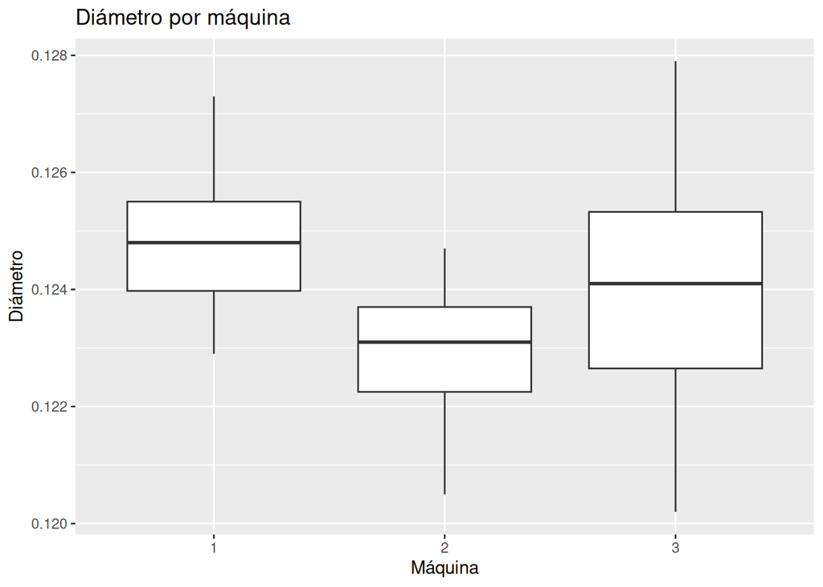

```r
ggplot(machine, aes(x = MACHINE, y = DIAMETER)) +
  geom_boxplot() +
  labs(
    title = "Diámetro por máquina",
    x = "Máquina",
    y = "Diámetro"
  )
```

# 6. La dispersión no es sólo “qué tan grande es la desviación estándar”

Una comparación estadística debe considerar:

- centro;
- escala;
- forma;
- valores extremos;
- contexto de medición.

## Actividad 3

Construye un pequeño reporte:

| Máquina | Media | Mediana | SD | IQR |
| --- | --- | --- | --- | --- |
| 1 |  |  |  |  |
| 2 |  |  |  |  |
| 3 |  |  |  |  |

Después responde:

1. ¿Qué máquina tiene mayor variabilidad según SD?
2. ¿Coincide con el IQR?
3. ¿Qué medida prefieres para una comparación robusta?
4. ¿Existe evidencia visual de valores atípicos?

# 7. Coeficiente de variación

Cuando tiene sentido trabajar con una variable positiva y una escala de razón:

$$CV=\frac{s}{\bar{x}}.$$

Como porcentaje:

$$CV(\%)=100\frac{s}{\bar{x}}.$$

```r
cv <- function(x) sd(x) / mean(x)

tapply(machine$DIAMETER, machine$MACHINE, cv) * 100
```

```
##         1         2         3
## 0.9172985 0.7513910 1.4801593
```

## Actividad 4

¿Por qué dividir por la media puede ser útil al comparar variabilidad relativa?

¿En qué situaciones NO sería razonable utilizar CV?

# 8. Comparación conceptual

Considera dos conjuntos hipotéticos:

$$A=\{99,100,101\}$$

$$B=\{50,100,150\}.$$

Ambos tienen media 100.

Calcula:

```r
A <- c(99,100,101)
B <- c(50,100,150)

c(mean(A), sd(A), IQR(A))
```

```
## [1] 100   1   1
```

```r
c(mean(B), sd(B), IQR(B))
```

```
## [1] 100  50  50
```

## Actividad 5

Explica por qué:

> “Las medias son iguales”

no implica

> “los conjuntos se comportan igual”.

# 9. Reto

Para cada máquina construye:

1. histograma;
2. boxplot;
3. tabla de media, mediana, SD e IQR.

Después escribe una conclusión de máximo 10 líneas.

Tu conclusión debe diferenciar claramente:

- centro;
- dispersión;
- forma;
- posibles valores extremos.

# Autoevaluación

**Checklist**

Debes poder:

- distinguir rango e IQR;
- explicar el divisor $n-1$ de la varianza muestral;
- relacionar varianza y desviación estándar;
- comparar distribuciones;
- explicar el concepto de variabilidad relativa;
- reconocer que dos muestras pueden tener igual media y distinta dispersión.